# Lesson 0: Getting started

Umberto Noe https://www.ed.ac.uk/profile/umberto-noe (Department of Psychology, The University of Edinburgh) , Josiah King https://www.ed.ac.uk/profile/josiah-pj-king (Department of Psychology, The University of Edinburgh)  
2021-05-31

## Reading

Required reading:

- [Chapter 1, Stat 545](https://stat545.com/install.html)

## Prelude

If you’re here it’s because you want to learn how to go from this

| species | island | bill_length_mm | bill_depth_mm | flipper_length_mm | body_mass_g | sex | year |
| --- | --- | --- | --- | --- | --- | --- | --- |
| Adelie | Torgersen | 39.1 | 18.7 | 181 | 3750 | male | 2007 |
| Adelie | Torgersen | 39.5 | 17.4 | 186 | 3800 | female | 2007 |
| Adelie | Torgersen | 40.3 | 18.0 | 195 | 3250 | female | 2007 |
| Adelie | Torgersen | NA | NA | NA | NA | NA | 2007 |
| Adelie | Torgersen | 36.7 | 19.3 | 193 | 3450 | female | 2007 |
| Adelie | Torgersen | 39.3 | 20.6 | 190 | 3650 | male | 2007 |
| Adelie | Torgersen | 38.9 | 17.8 | 181 | 3625 | female | 2007 |
| Adelie | Torgersen | 39.2 | 19.6 | 195 | 4675 | male | 2007 |
| Adelie | Torgersen | 34.1 | 18.1 | 193 | 3475 | NA | 2007 |
| Adelie | Torgersen | 42.0 | 20.2 | 190 | 4250 | NA | 2007 |

[output cut: 334 more lines]

to this

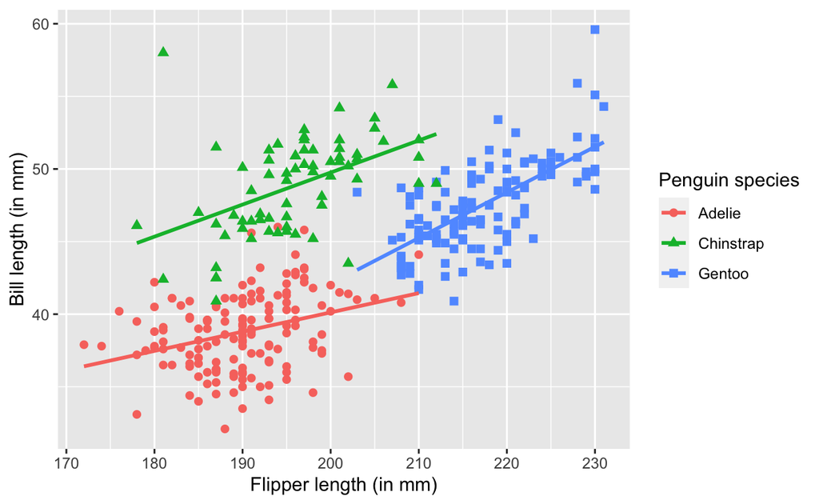

| Species | Count | Mean Bill Length | Std. Dev. Bill Length |
| --- | --- | --- | --- |
| Adelie | 152 | 38.79 | 2.66 |
| Chinstrap | 68 | 48.83 | 3.34 |
| Gentoo | 124 | 47.50 | 3.08 |

Collecting a large amount of data and looking at it in excel is not helpful for humans, it does not give us any insights or knowledge.

Knowledge is obtained by creating suitable summaries and visual displays from the data.

## What you need

To succeed in this bootcamp you will only need:

1. a laptop

**Note**: If you are using a Chromebook, please contact us via email.

2. active learning

Just reading the material won’t be enough, you need to type along the code and get familiar with errors.

3. willingness to learn

If you approach the material with an inquisitive attitude, it will be easier to learn.

Ready, set, go!

## What is R?

R is a programming language: an actual language that a computer can understand. The purpose of a programming language is to instruct the computer to do some boring and long computations on our behalf.

When you learn to program you are in fact learning a new language, just like English, Italian, and so on. The only difference is that, since we will be communicating with a machine, the language itself needs to be unambiguous, concise, and hence very limited in its grammar and scope. Basically, a programming language follows a very strict set of rules. The computer will do **exactly** what you type. It will not try to understand what you want it to do and, if you make an error in your language, the computer will not fix it, but it will just do what you say.

If you commit an error, there are two possible outcomes:

1. The computation goes ahead without any sign of errors nor messages. This is the most worrying type of error as it’s hard to catch. You will get a result for your computation, but it may make no sense.
2. The computer will tell you that what you’re asking to do doesn’t make sense. Easier to fix!

The programming language that you will learn is called R.

The code you type using the R programming language then will need to be converted to lower level instructions for the computer, such as “store this number into memory location with a specific address”. This is done by the **interpreter** which, is also called R. So R is both the programming language and the interpreter telling the computer what to do with your commands.

How does R look?

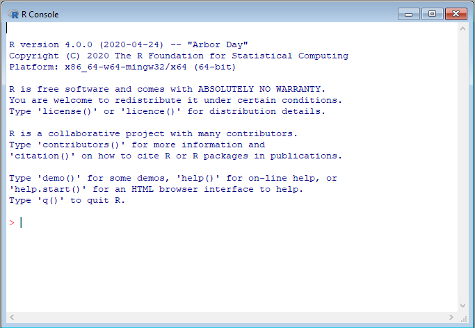

## Installing R (or updating R)

Click the section that applies to your specific PC to expand it.

**Installing for Windows**

### Windows PC

0. If you are updating R, uninstall all previous R or RTools programs you have installed in your PC.
1. [Install RTools](https://cran.r-project.org/bin/windows/Rtools/)
2. [Install R](https://cran.r-project.org/bin/windows/base/)

**Installing for macOS**

### macOS

0. If you are updating R, uninstall all previous R installations you have by moving the R icon from the Applications folder to the Bin.
1. [Install XQuartz](http://xquartz.macosforge.org/)
2. [Install R](https://cran.r-project.org/bin/macosx/). Click the release that has title R-Number.Number.Number.pkg (for example R-4.1.0.pkg but this will change in the future).

## What is RStudio?

RStudio is a nicer interface to R. It is simply a wrapper around R that combines a text editor, a file explorer, a help panel, and a graphics panel to see all your pictures.

Let’s have a look at it:

[figure not shown]

1. The **editor** is where you write you write your files with commands for the computer using the R language.

If you cannot see the editor, you have to open a new file. Click “File” -> “New file” -> “R Markdown”

2. The commands get then sent to the R **console**, which runs them and actually does the computation and displays the result.
3. The **environment** shows the things you have created, for example data.
4. The **plots and files** panel displays any plots you create and, if you click the files tab, it has a file explorer for you to find files and data stored in excel or similar.

## Installing RStudio (or updating RStudio)

0. If you have a previous version of RStudio already installed, uninstall it (if on Windows), or move it to the bin (if on a macOS).
1. At [this link](https://www.rstudio.com/products/rstudio/download/), scroll down until you see RStudio Desktop and “Download RStudio”.
2. Open RStudio, type the following in the console, and press Enter after each line

```
options(pkgType = "binary")
update.packages(ask = FALSE)
```

## Update regularly

It is IMPORTANT that you keep your R and RStudio installations up-to-date. If you don’t you will encounter many errors at some point.

- Try to update R at least twice a year.
- Try to update RStudio once every here.

## Postlude

Whenever we say “open R” or “using R”, what we really mean is “open RStudio” or “using RStudio”.

You should always using RStudio to write code. So, even if you will have two applications in your computer: R and RStudio, you will only need to open RStudio for your day-to-day work.